# Breast Cancer Wisconsin (Diagnostic) Data Set Term Project

## Breast Cancer Prediction Term Project

Our dataset describe 30 different characteristics of breast mass which are calculated in 3-dimentional space.[K. P. Bennett and O. L. Mangasarian: "Robust Linear Programming Discrimination of Two Linearly Inseparable Sets", Optimization Methods and Software 1, 1992, 23-34].

As an initial step, 10 different parameter were determined as a basis of measurement for diognosis which can be found with their explanations below, after that with these base parameters 30 different feature were created to include any predictive model.

#### Attribute Information:

1) ID number

2) Diagnosis (M = malignant, B = benign)

3-32)

#### Ten real-valued features are computed for each cell nucleus:

a) radius (mean of distances from center to points on the perimeter)

b) texture (standard deviation of gray-scale values)

c) perimeter

d) area

e) smoothness (local variation in radius lengths)

f) compactness (perimeter^2 / area - 1.0)

g) concavity (severity of concave portions of the contour)

h) concave points (number of concave portions of the contour)

i) symmetry

j) fractal dimension ("coastline approximation" - 1)

```python
import numpy as np
import pandas as pd
import seaborn as sns
import matplotlib.pyplot as plt
```

```python
url = "https://raw.githubusercontent.com/oguzkirazdiken/oguz.kirazdiken/master/Breast%20Cancer%20Wisconsin%20(Diagnostic)%20Data%20Set.csv"
```

```python
df = pd.read_csv(url)
```

```python
df.head()
```

|  | id | diagnosis | radius_mean | texture_mean | perimeter_mean | area_mean | smoothness_mean | compactness_mean | concavity_mean | concave points_mean | ... | texture_worst | perimeter_worst | area_worst | smoothness_worst | compactness_worst | concavity_worst | concave points_worst | symmetry_worst | fractal_dimension_worst | Unnamed: 32 |
| --- | --- | --- | --- | --- | --- | --- | --- | --- | --- | --- | --- | --- | --- | --- | --- | --- | --- | --- | --- | --- | --- |
| 0 | 842302 | M | 17.99 | 10.38 | 122.80 | 1001.0 | 0.11840 | 0.27760 | 0.3001 | 0.14710 | ... | 17.33 | 184.60 | 2019.0 | 0.1622 | 0.6656 | 0.7119 | 0.2654 | 0.4601 | 0.11890 | NaN |
| 1 | 842517 | M | 20.57 | 17.77 | 132.90 | 1326.0 | 0.08474 | 0.07864 | 0.0869 | 0.07017 | ... | 23.41 | 158.80 | 1956.0 | 0.1238 | 0.1866 | 0.2416 | 0.1860 | 0.2750 | 0.08902 | NaN |
| 2 | 84300903 | M | 19.69 | 21.25 | 130.00 | 1203.0 | 0.10960 | 0.15990 | 0.1974 | 0.12790 | ... | 25.53 | 152.50 | 1709.0 | 0.1444 | 0.4245 | 0.4504 | 0.2430 | 0.3613 | 0.08758 | NaN |
| 3 | 84348301 | M | 11.42 | 20.38 | 77.58 | 386.1 | 0.14250 | 0.28390 | 0.2414 | 0.10520 | ... | 26.50 | 98.87 | 567.7 | 0.2098 | 0.8663 | 0.6869 | 0.2575 | 0.6638 | 0.17300 | NaN |
| 4 | 84358402 | M | 20.29 | 14.34 | 135.10 | 1297.0 | 0.10030 | 0.13280 | 0.1980 | 0.10430 | ... | 16.67 | 152.20 | 1575.0 | 0.1374 | 0.2050 | 0.4000 | 0.1625 | 0.2364 | 0.07678 | NaN |

5 rows × 33 columns

### Explanatory Analysis For Understanding

```python
data = df.iloc[:, 1:32]
```

```
B    357
M    212
Name: diagnosis, dtype: int64
```

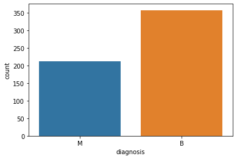

```python
sns.countplot(data.diagnosis,label="Count")
data.diagnosis.value_counts()
```

There are 357 benign - 212 malignant observation in our dataset, so having slightly close number of observations with different results in our dataset is very important to set up correct model. This ratio also need to be preserved in test and training sets.

### Number of outliers for each column

```python
data.describe()
```

|  | radius_mean | texture_mean | perimeter_mean | area_mean | smoothness_mean | compactness_mean | concavity_mean | concave points_mean | symmetry_mean | fractal_dimension_mean | ... | radius_worst | texture_worst | perimeter_worst | area_worst | smoothness_worst | compactness_worst | concavity_worst | concave points_worst | symmetry_worst | fractal_dimension_worst |
| --- | --- | --- | --- | --- | --- | --- | --- | --- | --- | --- | --- | --- | --- | --- | --- | --- | --- | --- | --- | --- | --- |
| count | 569.000000 | 569.000000 | 569.000000 | 569.000000 | 569.000000 | 569.000000 | 569.000000 | 569.000000 | 569.000000 | 569.000000 | ... | 569.000000 | 569.000000 | 569.000000 | 569.000000 | 569.000000 | 569.000000 | 569.000000 | 569.000000 | 569.000000 | 569.000000 |
| mean | 14.127292 | 19.289649 | 91.969033 | 654.889104 | 0.096360 | 0.104341 | 0.088799 | 0.048919 | 0.181162 | 0.062798 | ... | 16.269190 | 25.677223 | 107.261213 | 880.583128 | 0.132369 | 0.254265 | 0.272188 | 0.114606 | 0.290076 | 0.083946 |
| std | 3.524049 | 4.301036 | 24.298981 | 351.914129 | 0.014064 | 0.052813 | 0.079720 | 0.038803 | 0.027414 | 0.007060 | ... | 4.833242 | 6.146258 | 33.602542 | 569.356993 | 0.022832 | 0.157336 | 0.208624 | 0.065732 | 0.061867 | 0.018061 |
| min | 6.981000 | 9.710000 | 43.790000 | 143.500000 | 0.052630 | 0.019380 | 0.000000 | 0.000000 | 0.106000 | 0.049960 | ... | 7.930000 | 12.020000 | 50.410000 | 185.200000 | 0.071170 | 0.027290 | 0.000000 | 0.000000 | 0.156500 | 0.055040 |
| 25% | 11.700000 | 16.170000 | 75.170000 | 420.300000 | 0.086370 | 0.064920 | 0.029560 | 0.020310 | 0.161900 | 0.057700 | ... | 13.010000 | 21.080000 | 84.110000 | 515.300000 | 0.116600 | 0.147200 | 0.114500 | 0.064930 | 0.250400 | 0.071460 |
| 50% | 13.370000 | 18.840000 | 86.240000 | 551.100000 | 0.095870 | 0.092630 | 0.061540 | 0.033500 | 0.179200 | 0.061540 | ... | 14.970000 | 25.410000 | 97.660000 | 686.500000 | 0.131300 | 0.211900 | 0.226700 | 0.099930 | 0.282200 | 0.080040 |
| 75% | 15.780000 | 21.800000 | 104.100000 | 782.700000 | 0.105300 | 0.130400 | 0.130700 | 0.074000 | 0.195700 | 0.066120 | ... | 18.790000 | 29.720000 | 125.400000 | 1084.000000 | 0.146000 | 0.339100 | 0.382900 | 0.161400 | 0.317900 | 0.092080 |
| max | 28.110000 | 39.280000 | 188.500000 | 2501.000000 | 0.163400 | 0.345400 | 0.426800 | 0.201200 | 0.304000 | 0.097440 | ... | 36.040000 | 49.540000 | 251.200000 | 4254.000000 | 0.222600 | 1.058000 | 1.252000 | 0.291000 | 0.663800 | 0.207500 |

8 rows × 30 columns

```python
Q1 = data.drop(['diagnosis'],axis=1).quantile(0.25)
Q3 = data.drop(['diagnosis'],axis=1).quantile(0.75)
IQR = Q3 - Q1
```

```python
((data.drop(['diagnosis'],axis=1) < (Q1 - 1.5 * IQR)) | (data.drop(['diagnosis'],axis=1) > (Q3 + 1.5 * IQR))).sum()
```

```
radius_mean                14
texture_mean                7
perimeter_mean             13
area_mean                  25
smoothness_mean             6
compactness_mean           16
concavity_mean             18
concave points_mean        10
symmetry_mean              15
fractal_dimension_mean     15
radius_se                  38
texture_se                 20
perimeter_se               38
area_se                    65
smoothness_se              30
compactness_se             28
concavity_se               22
concave points_se          19
symmetry_se                27
fractal_dimension_se       28
radius_worst               17
texture_worst               5
perimeter_worst            15
area_worst                 35
smoothness_worst            7
compactness_worst          16
concavity_worst            12
concave points_worst        0
symmetry_worst             23
fractal_dimension_worst    24
dtype: int64
```

There are some outlier values for evey individual feature, but as we can see some of features like 'concave points_worst' don't have any or for other this value is less than 10. We can not evaluate any observation as an outlier.

### Correlation Analysis Between Features

As I mentioned before, the calculated features were defined from 10 different base parameter and while creating the data features the mean , standart error(se) and the mean of worst 3 values taken into consideration. In this case while examining the correlation of features, it is necessary to examine it within its individual group.

```python
features_mean= list(data.columns[1:11])
features_se= list(data.columns[11:21])
features_worst=list(data.columns[21:31])
```

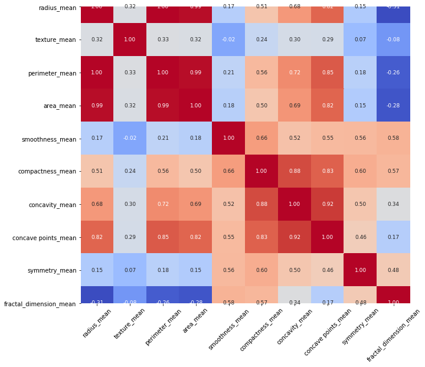

```python
corr_mean = data[features_mean].corr()
plt.figure(figsize=(10,10))

sns.heatmap(corr_mean, cbar = False,  square = True, annot=True, fmt= '.2f',annot_kws={'size': 9},
           xticklabels= features_mean, yticklabels= features_mean,
           cmap= 'coolwarm')
plt.xticks(rotation = 45)
```

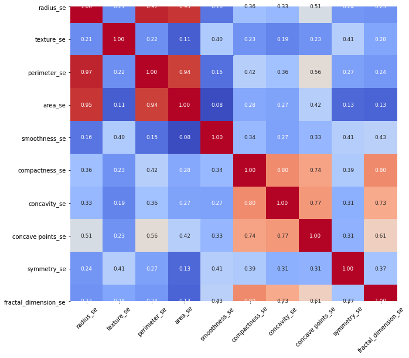

```python
corr_se = data[features_se].corr()
plt.figure(figsize=(10,10))

sns.heatmap(corr_se, cbar = False,  square = True, annot=True, fmt= '.2f',annot_kws={'size': 9},
           xticklabels= features_se, yticklabels= features_se,
           cmap= 'coolwarm')
plt.xticks(rotation = 45)
```

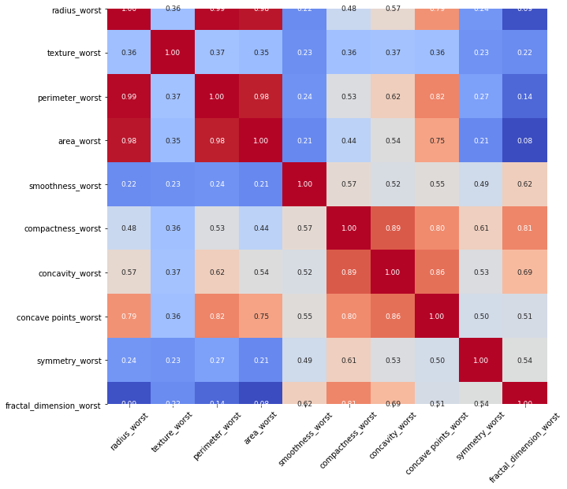

```python
corr_se = data[features_worst].corr()
plt.figure(figsize=(10,10))

sns.heatmap(corr_se, cbar = False,  square = True, annot=True, fmt= '.2f',annot_kws={'size': 9},
           xticklabels= features_worst, yticklabels= features_worst,
           cmap= 'coolwarm')
plt.xticks(rotation = 45)
```

Generally in three correlation heatmap, it is obvious that for all mean,se and worst features there are some correlations between;

radius - perimeter

radius - area

perimeter - area

radius - concave_points

perimeter - concave_points

compactness - concave_points

compactness - concavity

concavity - concave_points

compactness - fractional_dimention

### General Correlation Heatmap

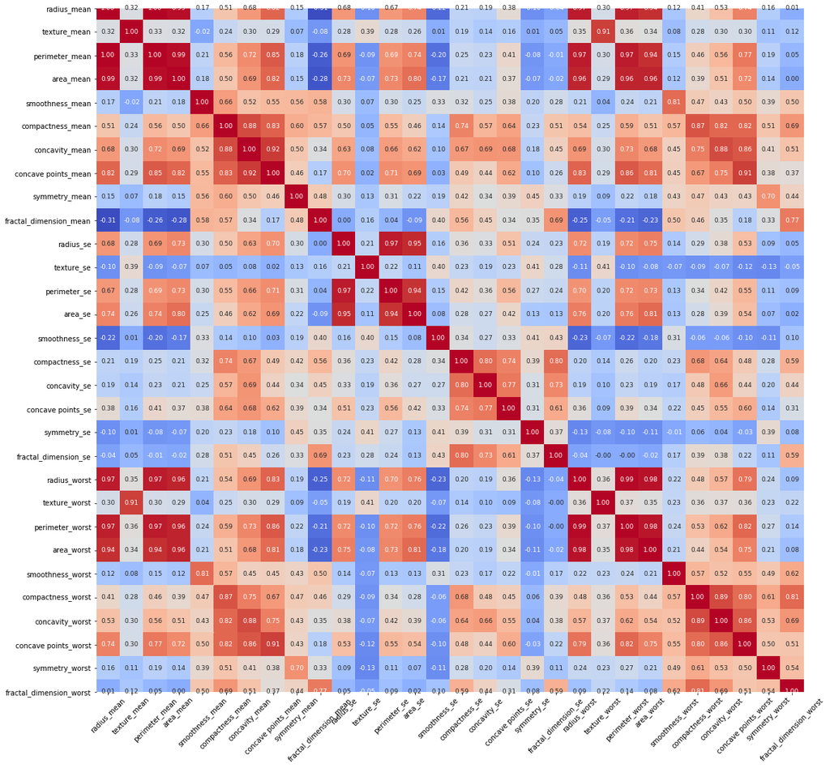

```python
corr = data.corr()
plt.figure(figsize=(18,18))

sns.heatmap(corr, cbar = False,  square = True, annot=True, fmt= '.2f',annot_kws={'size': 9},
           cmap= 'coolwarm')
plt.xticks(rotation = 45)
```

### Model Selection According to Cross Validation Score

The purpose of the function we define below is to measure the accuracy of predictions in train and test sets individually when different models are fitted to our train set. It is also examining the cross validation scores to be sure about if we are obtaining the same accuracy for every split of the data.

```python
import warnings
warnings.filterwarnings("ignore")
```

```python
from sklearn.model_selection import train_test_split
```

```python
df['diagnosis'] = df['diagnosis'].map({'M':1,'B':0})
```

```python
df.drop('id',axis=1,inplace=True)
df.drop('Unnamed: 32',axis=1,inplace=True)
```

```python
from sklearn import metrics
```

```python
traindf, testdf = train_test_split(df, test_size = 0.3)
```

```python
from sklearn.model_selection import cross_val_score
```

```python
def classification_model(model,trainset,testset,predictors, outcome):

        model.fit(trainset[predictors],trainset[outcome])

        trainset_predictions = model.predict(trainset[predictors])

        trainset_accuracy = metrics.accuracy_score(trainset_predictions,trainset[outcome])

        print("Trainset Accuracy : %s" % "{0:.3%}".format(trainset_accuracy))

        print("Trainset Cross Validation Scores : ",cross_val_score(model, trainset[predictors], trainset[outcome], cv=5))

        testset_predictions = model.predict(testset[predictors])

        testset_accuracy = metrics.accuracy_score(testset_predictions,testset[outcome])

        print("Testset Accuracy : %s" % "{0:.3%}".format(testset_accuracy))

        print("Testset Cross Validation Scores : ",cross_val_score(model, testset[predictors], testset[outcome], cv=5))
```

### Logistic Regression

```python
from sklearn.linear_model import LogisticRegression
```

```python
predictor_var = list(df.columns)[1:]

outcome_var='diagnosis'

model=LogisticRegression()

classification_model(model,traindf,testdf,predictor_var,outcome_var)
```

```
Trainset Accuracy : 96.482%
Trainset Cross Validation Scores :  [0.91358025 0.95       0.96202532 0.97468354 0.97468354]
Testset Accuracy : 94.152%
Testset Cross Validation Scores :  [0.91428571 0.97058824 1.         0.88235294 0.91176471]
```

### DecisionTree Model

```python
from sklearn.tree import DecisionTreeClassifier
```

```python
predictor_var = list(df.columns)[1:]

model = DecisionTreeClassifier()

classification_model(model,traindf,testdf,predictor_var,outcome_var)
```

```
Trainset Accuracy : 100.000%
Trainset Cross Validation Scores :  [0.88888889 0.85       0.92405063 0.94936709 0.93670886]
Testset Accuracy : 91.813%
Testset Cross Validation Scores :  [0.88571429 0.91176471 0.94117647 0.91176471 0.94117647]
```

In the decision tree model, there is a big difference between test and train sets predictions accuracy. This may point the overfitting. The low value of all cross validation scores in every split supports the issue.

### Random Forest

```python
from sklearn.ensemble import RandomForestClassifier
```

```python
predictor_var = list(df.columns)[1:]

model = RandomForestClassifier()

classification_model(model,traindf,testdf,predictor_var,outcome_var)
```

```
Trainset Accuracy : 99.497%
Trainset Cross Validation Scores :  [0.9382716  0.9625     0.94936709 0.96202532 0.96202532]
Testset Accuracy : 97.076%
Testset Cross Validation Scores :  [0.94285714 0.97058824 1.         0.94117647 0.97058824]
```

The random forest model provides close and highly accurate predictions in both cross validation scores and train / test sets.

### Selecting Features with KBest

In the following study, it is tried to examine with KBest algorithm that what is the importance of each feature for the model accuracy.

```python
from sklearn.model_selection import train_test_split
from sklearn.ensemble import RandomForestClassifier
from sklearn.metrics import f1_score,confusion_matrix
from sklearn.metrics import accuracy_score
```

```python
from sklearn.feature_selection import SelectKBest
from sklearn.feature_selection import chi2
```

```python
y = df.loc[:,'diagnosis']
```

```python
x = df.loc[:,'radius_mean':'fractal_dimension_worst']
```

```python
x_train, x_test, y_train, y_test = train_test_split(x, y, test_size=0.3)
```

```python
y_test.value_counts()
```

```
0    96
1    75
Name: diagnosis, dtype: int64
```

```python
y_train.value_counts()
```

```
0    261
1    137
Name: diagnosis, dtype: int64
```

```
Accuracy is:  0.9415204678362573
```

```
array([[94,  2],
       [ 8, 67]], dtype=int64)
```

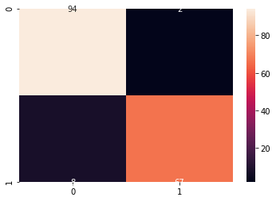

```python
clf_rf = RandomForestClassifier()

clr_rf = clf_rf.fit(x_train,y_train)

ac = accuracy_score(y_test,clf_rf.predict(x_test))

print('Accuracy is: ',ac)

cm = confusion_matrix(y_test,clf_rf.predict(x_test))

sns.heatmap(cm,annot=True,fmt="d")

cm
```

```python
select_feature = SelectKBest(chi2, k=15).fit(x_train,y_train)
```

```python
selected_cols = select_feature.get_support()
```

```python
scores_data = {'Features':  x.columns ,
        'Scores': select_feature.scores_ ,
        'Selected' : selected_cols}
```

```python
pd.DataFrame(scores_data)
```

|  | Features | Scores | Selected |
| --- | --- | --- | --- |
| 0 | radius_mean | 195.216613 | True |
| 1 | texture_mean | 78.191002 | True |
| 2 | perimeter_mean | 1473.760386 | True |
| 3 | area_mean | 40445.999024 | True |
| 4 | smoothness_mean | 0.100111 | False |
| 5 | compactness_mean | 3.573364 | False |
| 6 | concavity_mean | 14.343507 | True |
| 7 | concave points_mean | 7.563819 | False |
| 8 | symmetry_mean | 0.128688 | False |
| 9 | fractal_dimension_mean | 0.001062 | False |
| 10 | radius_se | 27.094301 | True |
| 11 | texture_se | 0.029695 | False |
| 12 | perimeter_se | 196.352032 | True |
| 13 | area_se | 6986.677803 | True |
| 14 | smoothness_se | 0.004308 | False |
| 15 | compactness_se | 0.446580 | False |
| 16 | concavity_se | 0.768550 | False |
| 17 | concave points_se | 0.214973 | False |
| 18 | symmetry_se | 0.000661 | False |
| 19 | fractal_dimension_se | 0.003200 | False |
| 20 | radius_worst | 356.616943 | True |
| 21 | texture_worst | 142.594591 | True |
| 22 | perimeter_worst | 2682.296986 | True |
| 23 | area_worst | 83867.351305 | True |
| 24 | smoothness_worst | 0.253784 | False |
| 25 | compactness_worst | 14.327364 | True |
| 26 | concavity_worst | 30.397553 | True |
| 27 | concave points_worst | 9.560303 | True |
| 28 | symmetry_worst | 0.737006 | False |
| 29 | fractal_dimension_worst | 0.151533 | False |

In the list above, you can see the importance score of each feature and which of 15 features are selected.

```python
x_train_2 = select_feature.transform(x_train)

x_test_2 = select_feature.transform(x_test)
```

```
Accuracy is:  0.9590643274853801
```

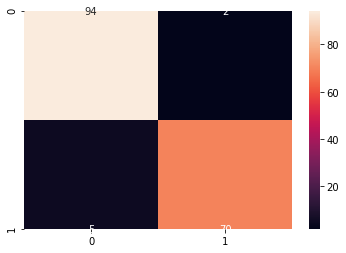

```python
clf_rf_2 = RandomForestClassifier()

clr_rf_2 = clf_rf_2.fit(x_train_2,y_train)

ac_2 = accuracy_score(y_test,clf_rf_2.predict(x_test_2))

print('Accuracy is: ',ac_2)

cm_2 = confusion_matrix(y_test,clf_rf_2.predict(x_test_2))

sns.heatmap(cm_2,annot=True,fmt="d")
```

```python
scores_data = pd.DataFrame(scores_data).iloc[:,0:2]
```

```python
pd.concat([scores_data.iloc[0:10,:].reset_index(drop=True), scores_data.iloc[10:20,:].reset_index(drop=True), scores_data.iloc[20:30,:].reset_index(drop=True)], axis=1)
```

|  | Features | Scores | Features | Scores | Features | Scores |
| --- | --- | --- | --- | --- | --- | --- |
| 0 | radius_mean | 195.216613 | radius_se | 27.094301 | radius_worst | 356.616943 |
| 1 | texture_mean | 78.191002 | texture_se | 0.029695 | texture_worst | 142.594591 |
| 2 | perimeter_mean | 1473.760386 | perimeter_se | 196.352032 | perimeter_worst | 2682.296986 |
| 3 | area_mean | 40445.999024 | area_se | 6986.677803 | area_worst | 83867.351305 |
| 4 | smoothness_mean | 0.100111 | smoothness_se | 0.004308 | smoothness_worst | 0.253784 |
| 5 | compactness_mean | 3.573364 | compactness_se | 0.446580 | compactness_worst | 14.327364 |
| 6 | concavity_mean | 14.343507 | concavity_se | 0.768550 | concavity_worst | 30.397553 |
| 7 | concave points_mean | 7.563819 | concave points_se | 0.214973 | concave points_worst | 9.560303 |
| 8 | symmetry_mean | 0.128688 | symmetry_se | 0.000661 | symmetry_worst | 0.737006 |
| 9 | fractal_dimension_mean | 0.001062 | fractal_dimension_se | 0.003200 | fractal_dimension_worst | 0.151533 |

According to result of KBest, worst terms of features have relatively higher importance score rather then others. That means if there is any need to decrease number of features for model in order to find optimal computing time, these features needed to be selected with higher priority.

```python
from sklearn.metrics import precision_score
from sklearn.metrics import recall_score
```

```python
measures = ["accuracy with means","accuracy with se","accuracy with worst"]

for i in range(0,3):

    if i == 0 :

        clf = RandomForestClassifier()

        clf.fit(x_train.iloc[:,0:10],y_train)

        acc = accuracy_score(y_test,clf.predict(x_test.iloc[:,0:10]))

        pre = precision_score(y_test,clf.predict(x_test.iloc[:,0:10]))

        rec = recall_score(y_test,clf.predict(x_test.iloc[:,0:10]))

        print("Accuracy with mean features;",acc)

        print("Precision with mean features;",pre)

        print("Recall with mean features;",rec)

    elif i == 1 :

        clf = RandomForestClassifier()

        clf.fit(x_train.iloc[:,10:20],y_train)

        acc = accuracy_score(y_test,clf.predict(x_test.iloc[:,10:20]))

        pre = precision_score(y_test,clf.predict(x_test.iloc[:,10:20]))

        rec = recall_score(y_test,clf.predict(x_test.iloc[:,10:20]))

        print("Accuracy with se features;",acc)

        print("Precision with se features;",pre)

        print("Recall with se features;",rec)

    else :

        clf = RandomForestClassifier()

        clf.fit(x_train.iloc[:,20:30],y_train)

        acc = accuracy_score(y_test,clf.predict(x_test.iloc[:,20:30]))

        pre = precision_score(y_test,clf.predict(x_test.iloc[:,20:30]))

        rec = recall_score(y_test,clf.predict(x_test.iloc[:,20:30]))

        print("Accuracy with worst features;",acc)

        print("Precision with worst features;",pre)

        print("Recall with worst; features;",rec)
```

```
Accuracy with mean features; 0.9239766081871345
Precision with mean features; 0.9558823529411765
Recall with mean features; 0.8666666666666667
Accuracy with se features; 0.847953216374269
Precision with se features; 0.9152542372881356
Recall with se features; 0.72
Accuracy with worst features; 0.9590643274853801
Precision with worst features; 0.9473684210526315
Recall with worst; features; 0.96
```

```python
x_train = x_train.drop(["texture_se","smoothness_se","symmetry_se","fractal_dimension_se","fractal_dimension_mean"],axis=1)
```

```python
x_test = x_test.drop(["texture_se","smoothness_se","symmetry_se","fractal_dimension_se","fractal_dimension_mean"],axis=1)
```

```python
clf = RandomForestClassifier()

clf.fit(x_train,y_train)

acc = accuracy_score(y_test,clf.predict(x_test))

pre = precision_score(y_test,clf.predict(x_test))

rec = recall_score(y_test,clf.predict(x_test))

print("Accuracy with mean features;",acc)

print("Precision with mean features;",pre)

print("Recall with mean features;",rec)
```

```
Accuracy with mean features; 0.9590643274853801
Precision with mean features; 0.9473684210526315
Recall with mean features; 0.96
```

### Individual Contribution Of Each Feature

The purpose of the algorithm created in this section is to measure the individual contribution of each feature to model.

```python
acc_list = []

pre_list = []

rec_list = []

for i in range(0,25):

    clf_rf_2 = RandomForestClassifier()

    clf_rf_2.fit(pd.DataFrame(x_train.iloc[:,i]),y_train)

    ac_2 = accuracy_score(y_test,clf_rf_2.predict(pd.DataFrame(x_test.iloc[:,i])))

    pre = precision_score(y_test,clf_rf_2.predict(pd.DataFrame(x_test.iloc[:,i])))

    rec = recall_score(y_test,clf_rf_2.predict(pd.DataFrame(x_test.iloc[:,i])))

    acc_list.append(ac_2)

    pre_list.append(pre)

    rec_list.append(rec)
```

```python
indv_data = {"features": x_train.columns , "accuracy" : acc_list , "precision" : pre_list , "recall" : rec_list}
```

```python
pd.DataFrame(indv_data)
```

|  | features | accuracy | precision | recall |
| --- | --- | --- | --- | --- |
| 0 | radius_mean | 0.812865 | 0.794521 | 0.773333 |
| 1 | texture_mean | 0.596491 | 0.562500 | 0.360000 |
| 2 | perimeter_mean | 0.812865 | 0.794521 | 0.773333 |
| 3 | area_mean | 0.795322 | 0.777778 | 0.746667 |
| 4 | smoothness_mean | 0.578947 | 0.529412 | 0.360000 |
| 5 | compactness_mean | 0.742690 | 0.746032 | 0.626667 |
| 6 | concavity_mean | 0.807018 | 0.862069 | 0.666667 |
| 7 | concave points_mean | 0.847953 | 0.888889 | 0.746667 |
| 8 | symmetry_mean | 0.596491 | 0.562500 | 0.360000 |
| 9 | radius_se | 0.725146 | 0.700000 | 0.653333 |
| 10 | perimeter_se | 0.713450 | 0.732143 | 0.546667 |
| 11 | area_se | 0.748538 | 0.735294 | 0.666667 |
| 12 | compactness_se | 0.619883 | 0.586207 | 0.453333 |
| 13 | concavity_se | 0.590643 | 0.540984 | 0.440000 |
| 14 | concave points_se | 0.654971 | 0.621212 | 0.546667 |
| 15 | radius_worst | 0.888889 | 0.878378 | 0.866667 |
| 16 | texture_worst | 0.660819 | 0.626866 | 0.560000 |
| 17 | perimeter_worst | 0.865497 | 0.817073 | 0.893333 |
| 18 | area_worst | 0.888889 | 0.900000 | 0.840000 |
| 19 | smoothness_worst | 0.649123 | 0.666667 | 0.400000 |
| 20 | compactness_worst | 0.701754 | 0.706897 | 0.546667 |
| 21 | concavity_worst | 0.748538 | 0.758065 | 0.626667 |
| 22 | concave points_worst | 0.871345 | 0.863014 | 0.840000 |
| 23 | symmetry_worst | 0.660819 | 0.630769 | 0.546667 |
| 24 | fractal_dimension_worst | 0.649123 | 0.627119 | 0.493333 |

As seen in the table above, although many features give an average accuracy score but their precision and recall values observed lower.

In the model we created, false positive or false negative values are also important.These values should be kept as low as possible.Because otherwise, someone who does not have cancer can be diagnosed with cancer or cells with cancer can be missed.

For this reason, features that create a low recall or precision value can be eliminated.

```python
x_train = x_train.drop(["fractal_dimension_worst","symmetry_worst","smoothness_worst","texture_worst","concave points_se",
                       "concavity_se","compactness_se","symmetry_mean","compactness_mean","smoothness_mean","texture_mean"],axis=1)
```

```python
x_test = x_test.drop(["fractal_dimension_worst","symmetry_worst","smoothness_worst","texture_worst","concave points_se",
                       "concavity_se","compactness_se","symmetry_mean","compactness_mean","smoothness_mean","texture_mean"],axis=1)
```

```
Accuracy with mean features; 0.9590643274853801
Precision with mean features; 0.9594594594594594
Recall with mean features; 0.9466666666666667
```

```
array([[93,  3],
       [ 4, 71]], dtype=int64)
```

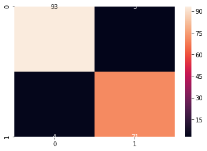

```python
clf = RandomForestClassifier()

clf.fit(x_train,y_train)

acc = accuracy_score(y_test,clf.predict(x_test))

pre = precision_score(y_test,clf.predict(x_test))

rec = recall_score(y_test,clf.predict(x_test))

print("Accuracy with mean features;",acc)

print("Precision with mean features;",pre)

print("Recall with mean features;",rec)

cm_2 = confusion_matrix(y_test,clf.predict(x_test))

sns.heatmap(cm_2,annot=True,fmt="d")

cm_2
```

### Hyperparameter Tuning

```python
from sklearn.model_selection import GridSearchCV
```

```python
clf = RandomForestClassifier()

param_grid = {
    'min_samples_split': [3, 5, 10],
    'n_estimators' : [100, 300],
    'max_depth': [3, 5, 15],
    'max_features': [3, 5, 10]
}

grid_search = GridSearchCV(clf, param_grid, scoring="accuracy",cv=5)

grid_search.fit(x_train, y_train)

print(grid_search.best_params_)

grid_search.best_score_
```

```
{'max_depth': 3, 'max_features': 3, 'min_samples_split': 10, 'n_estimators': 100}
```

```
0.9472361809045227
```

```python
grid_search = GridSearchCV(clf, param_grid, scoring="precision",cv=5)

grid_search.fit(x_train, y_train)

print(grid_search.best_params_)

grid_search.best_score_
```

```
{'max_depth': 3, 'max_features': 5, 'min_samples_split': 5, 'n_estimators': 100}
```

```
0.9479699065126201
```

```python
grid_search = GridSearchCV(clf, param_grid, scoring="recall",cv=5)

grid_search.fit(x_train, y_train)

print(grid_search.best_params_)

grid_search.best_score_
```

```
{'max_depth': 5, 'max_features': 3, 'min_samples_split': 10, 'n_estimators': 100}
```

```
0.9194716971098881
```

```python
clf = RandomForestClassifier(max_depth = 3 , max_features = 3 , min_samples_split= 10 , n_estimators= 300)

clf.fit(x_train,y_train)

acc = accuracy_score(y_test,clf.predict(x_test))

pre = precision_score(y_test,clf.predict(x_test))

rec = recall_score(y_test,clf.predict(x_test))

print("Accuracy with mean features;",acc)

print("Precision with mean features;",pre)

print("Recall with mean features;",rec)

confusion_matrix(y_test,clf.predict(x_test))
```

```
Accuracy with mean features; 0.9473684210526315
Precision with mean features; 0.9342105263157895
Recall with mean features; 0.9466666666666667
```

```
array([[91,  5],
       [ 4, 71]], dtype=int64)
```